# Final Project

STAT 230 Spring 2025

Author

Subhi Hammoudeh

```r
# load needed libraries
library(tidyverse)
```

# Data

What data set are you using? I’m using data showing the people who received their full vaccination or booster shots for covid.

Variable Type COUNTRY Categorical nominal ISO3 Categorical nominal WHO_REGION Categorical nominal DATA_SOURCE Categorical nominal DATE_UPDATED Numeric discrete TOTAL_VACCINATIONS Numeric discrete TOTAL_VACCINATIONS_PER100 Numeric continuous rate PERSONS_VACCINATED_1PLUS_DOSE Numeric discrete PERSONS_VACCINATED_1PLUS_DOSE_PER100 Numeric continuous PERSONS_FULLY_VACCINATED Numeric`discrete PERSONS_FULLY_VACCINATED_PER100 Numeric continuous NUMBER_VACCINES_TYPES_USED Numeric discrete PERSONS_BOOSTER_ADD_DOSE Numeric discrete PERSONS_BOOSTER_ADD_DOSE_PER100 Numeric continuous

#Read data in:

```r
vacc <- read_csv(
  "https://srhdpeuwpubsa.blob.core.windows.net/whdh/COVID/vaccination-data.csv",
  show_col_types = FALSE
)
```

# Questions

What questions are you going to answer with this data set?

Is there a correlation between vaccination rate and booster uptake across countries?

# Plots

Full Vaccination Coverage:

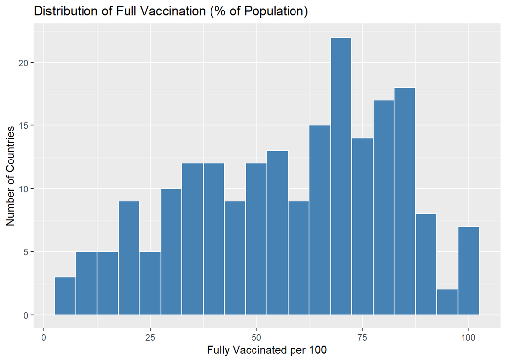

```r
ggplot(vacc, aes(x = PERSONS_LAST_DOSE_PER100)) +
  geom_histogram(binwidth = 5, fill = "steelblue", color = "white") +
  labs(
    title = "Distribution of Full Vaccination (% of Population)",
    x = "Fully Vaccinated per 100",
    y = "Number of Countries"
  )
```

#interpretation:

We can see that between the 65-75% of the population has received full vaccination in more than 15 different countries, the Gplot also shows that a lot of countries float around 40-50% full vaccination while some countries have over 90%. There’s also 5-10 countries that have lowest vaccination percentile.

#Booster Uptake per Region

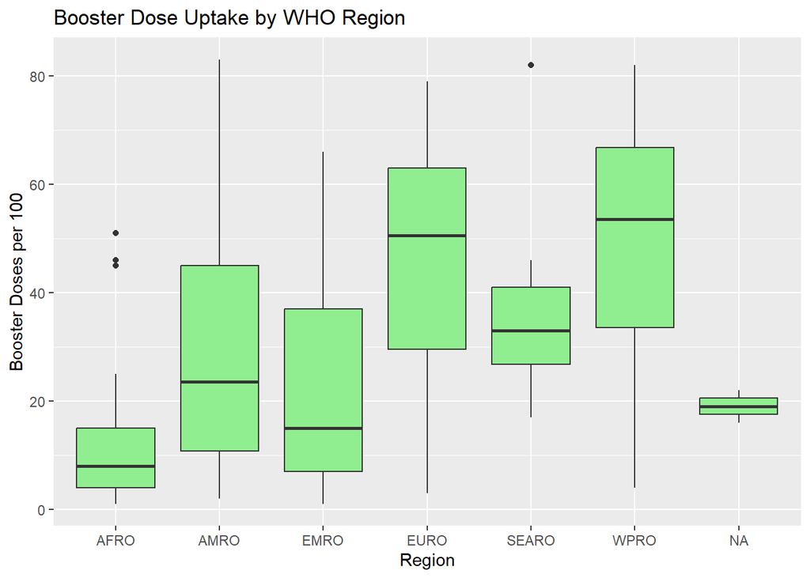

```r
ggplot(vacc, aes(x = WHO_REGION, y = PERSONS_BOOSTER_ADD_DOSE_PER100)) +
  geom_boxplot(fill = "lightgreen") +
  labs(
    title = "Booster Dose Uptake by WHO Region",
    x = "Region",
    y = "Booster Doses per 100"
  )
```

#interpretation:

According to the box-plot from the data provided, when it comes to regions, AFRO (Africa), has the lowest doses only around 9-10 per 100 people, while countries that have higher Booster Doses such as, Europe (EURO), Western Pacific (WRPO), and South East Asia (SEARO), have one of the highest medians when it comes to booster and doses per 100 people, Countries such as Eastern Mediterranean (EMRO) float just under 20 doses and America (AMRO), also floats around 20-25. Africa lags farthest in booster coverage, Europe, Western Pacific, the Americas, and Eastern Mediterranean show the greatest within-region disparities.

#Booster Vs Full Vaccination

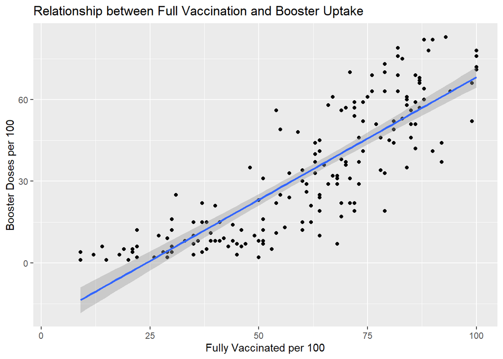

```r
ggplot(vacc, aes(x = PERSONS_LAST_DOSE_PER100, y = PERSONS_BOOSTER_ADD_DOSE_PER100)) +
  geom_point() +
  geom_smooth(method = "lm", se = TRUE) +
  labs(
    title = "Relationship between Full Vaccination and Booster Uptake",
    x = "Fully Vaccinated per 100",
    y = "Booster Doses per 100"
  )
```

#interpretation

We can see as a country’s full-vaccination rate goes up, its booster uptake tends to go up too—points slope upward from left to right. Most countries with <30 % fully vaccinated also have very low booster rates, while those >80 % fully vaccinated often reach 50–70 boosters per 100

#Summary Statistics by Region

```r
summary_stats <- vacc %>%
  group_by(WHO_REGION) %>%
  summarise(
    mean_full = mean(PERSONS_LAST_DOSE_PER100, na.rm = TRUE),
    sd_full   = sd(PERSONS_LAST_DOSE_PER100, na.rm = TRUE),
    min_full  = min(PERSONS_LAST_DOSE_PER100, na.rm = TRUE),
    max_full  = max(PERSONS_LAST_DOSE_PER100, na.rm = TRUE)
  )
summary_stats
```

```
# A tibble: 7 × 5
  WHO_REGION mean_full sd_full min_full max_full
  <chr>          <dbl>   <dbl>    <dbl>    <dbl>
1 AFRO            37.2   21.0         9       86
2 AMRO            62.3   21.2         3       94
3 EMRO            50.2   25.9         3       99
4 EURO            61.5   18.1        14       87
5 SEARO           73.6    9.70       61       88
6 WPRO            77.6   20.6         4      100
7 <NA>            33.5    4.95       30       37
```

#Interpretation

We can see that Africa (AFRO) Lags behind on vaccination making it the lowest in all regions sitting at a mean of only 37 per 100, Africa’s fully vaccinated proportion is well below the global average (~62 per 100).

#Full Vaccination Coverage per Region

```r
anova_res <- aov(PERSONS_LAST_DOSE_PER100 ~ WHO_REGION, data = vacc)
summary(anova_res)
```

```
             Df Sum Sq Mean Sq F value  Pr(>F)
WHO_REGION    5  35880    7176   17.09 4.7e-14 ***
Residuals   199  83537     420
---
Signif. codes:  0 '***' 0.001 '**' 0.01 '*' 0.05 '.' 0.1 ' ' 1
10 observations deleted due to missingness
```

#Interpretation

According to Anova the rates between the mean full-vaccination rates across different regions yielded F(5, 199) = 17.09, p < 0.0001, showing that there’s a high differences between regions in their average coverage.

#Correlation & Linear Regression: Boosters ~ Full Coverage

```r
cor_res <- cor.test(
  vacc$PERSONS_BOOSTER_ADD_DOSE_PER100,
  vacc$PERSONS_LAST_DOSE_PER100,
  use = "complete.obs"
)
cor_res
```

```
    Pearson's product-moment correlation

data:  vacc$PERSONS_BOOSTER_ADD_DOSE_PER100 and vacc$PERSONS_LAST_DOSE_PER100
t = 21.304, df = 182, p-value < 2.2e-16
alternative hypothesis: true correlation is not equal to 0
95 percent confidence interval:
 0.7976828 0.8817491
sample estimates:
      cor
0.8448531
```

```r
lm_res <- lm(
  PERSONS_BOOSTER_ADD_DOSE_PER100 ~ PERSONS_LAST_DOSE_PER100,
  data = vacc
)
summary(lm_res)
```

```
Call:
lm(formula = PERSONS_BOOSTER_ADD_DOSE_PER100 ~ PERSONS_LAST_DOSE_PER100,
    data = vacc)

Residuals:
    Min      1Q  Median      3Q     Max
-32.413  -8.192  -0.169   9.207  29.183

Coefficients:
                          Estimate Std. Error t value Pr(>|t|)
(Intercept)              -21.76973    2.74528   -7.93 2.14e-13 ***
PERSONS_LAST_DOSE_PER100   0.89975    0.04223   21.30  < 2e-16 ***
---
Signif. codes:  0 '***' 0.001 '**' 0.01 '*' 0.05 '.' 0.1 ' ' 1

Residual standard error: 12.85 on 182 degrees of freedom
  (31 observations deleted due to missingness)
Multiple R-squared:  0.7138,    Adjusted R-squared:  0.7122
F-statistic: 453.9 on 1 and 182 DF,  p-value: < 2.2e-16
```

#Interpretation We can see that the full vaccination strongly predicts the higher booster update. The Correlation, there’s a strong relationship between the full vaccination and the booster update, when countries have higher full vaccination, they tend to also have a high booster rates.

#render HTML quarto::quarto_render(“Final_Project.qmd”)

#Conclusion:

I also analyzed the relationship between booster uptake and full vaccination rates. I performed a correlation test that provided me with (r = 0.85). The results show that for every point increase in full-series coverage, there will be about 0.9 more boosters per 100 people. Around 71 percent of the differences in booster rates between nations can be explained by data that I generated using the DATA . Increasing primary-series coverage leads to a higher booster distribution.